# 7 Role of Anopheles Mosquitoes in Malaria Transmission

We will recap and delve into more details introduced in the previous topic and discuss the relevance to malaria transmission.

As a reminder, there are about 500 Anopheles species in the world. However, only 30 to 40 are considered important vectors of human malaria. These species are spread throughout the globe, as seen here in Figure 7.1, and they have very different behaviors during larval and adult stages. During larval development, which lasts about 7 to 10 days, mosquito are adapted to very different ecological habitats. Some mosquito species for instance, prefer breeding in temporary breeding sites, such as those provided by rain puddles. While others would prefer breeding in permanent breeding sites, such as rice fields. Some mosquitoes are highly adapted to salt water, and so live in coastal areas. While other mosquitoes can only survive in fresh water. These different ecological habitats expose mosquitoes to different environments. For instance, different temperature conditions and temperature shifts between day and night, also different microorganisms, predators, and nutritional reserves. In turn, the ecological habitats to which these mosquitoes are exposed as larvae will impact the physiology of adults emerging from those breeding sites, with possible consequences for malaria transmission. For instance, larvae that are adapted to temporary breeding sites, might have reduced availability of nutrients and might have a shorter developmental time. So the adults emerging from those breeding sites will generally be smaller in size and might need to feed more often as adults, on blood, in order to meet the energetic demands of flying, mating, reproducing, and so on. This in turn, might create more opportunities for Plasmodium parasites for their own transmissions, because a mosquito that bites more often obviously will be more capable of transmitting malaria.

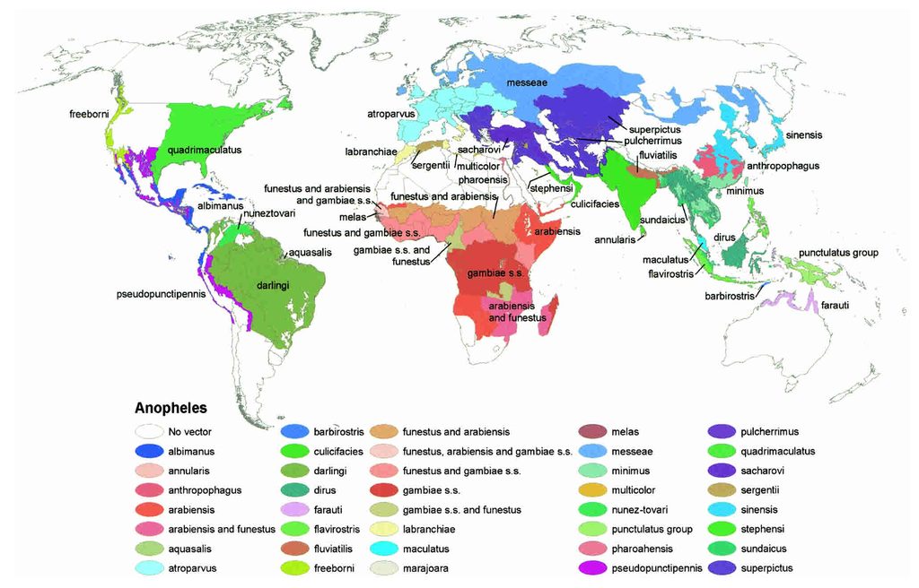

## 7.1 Vectors of Asia, Africa & the Americas

A great talk from the Ifakara Health Institute on Malaria Vectors

[video not shown]

## 7.2 Biology and Behavior of Anopheles Mosquitoes

As described in the previous chapter, malaria transmission is primarily driven by the Anopheles mosquito, which acts as the vector for the Plasmodium parasite. The biology and behavior of Anopheles mosquitoes are critical to their efficiency as vectors.

- **Feeding Behavior**: Female *Anopheles* mosquitoes are hematophagous, meaning they feed on blood to obtain the nutrients required for egg development. Their preference for human blood (anthropophily) makes them particularly effective vectors of malaria. Mosquitoes that feed primarily at night are most dangerous because they coincide with human sleep patterns, increasing the likelihood of undisturbed feeding. Blood feeding is really an essential component in the mosquito life cycle. And this is a step in which mosquitoes from different species exhibit quite a variety of behaviors.
  - Some mosquito species are highly adapted to feeding on humans. So they are highly anthropophilic. While other mosquito species predominantly feed on animals, such as birds, or cows, or rats. The propensity of a mosquito to feed on humans, rather than animals, can actually be measured. And this is the **human blood index**. The human blood index can be measured by collecting mosquitoes in the field and looking at the content of their blood to see whether it’s from animal or from human origin. This value goes from 0 to 1. With 0, being mosquitoes that feed exclusively on animals, so highly zoophilic. And 1, with mosquitoes that feed only on humans, so highly anthropophilic. Many mosquito species with a high level of anthropophilia actually cluster in Africa. And these mosquitoes belong to mosquitoes of the *Anopheles gambiae complex*, such as *Anopheles gambiae*, *Anopheles coluzzii*. But also, *Anopheles funestus*, which is another very important vector of human malaria in Africa.
- **Resting Behavior**: After feeding, *Anopheles* mosquitoes typically rest indoors (endophily) or outdoors (exophily). Indoor resting mosquitoes are targeted by indoor residual spraying (IRS) and insecticide-treated nets (ITNs), which are effective control strategies.
- **Flight Range**: *Anopheles* mosquitoes generally have a limited flight range, typically staying within a few kilometers of their breeding sites. However, their ability to locate humans through carbon dioxide and body odor means that even small numbers of mosquitoes can sustain transmission if they are close to human habitation.

## 7.3 Vector Competence and Efficiency

Not all *Anopheles* species are equally competent malaria vectors. Vector competence refers to the mosquito’s ability to acquire, maintain, and transmit the malaria parasite. This competence is influenced by factors such as:

- **Susceptibility to Infection**: Some *Anopheles* species are more susceptible to *Plasmodium* infection, meaning they are more likely to become infected after feeding on an infected person.
- **Parasite Development**: The development of the malaria parasite within the mosquito, known as the extrinsic incubation period, must be completed before the mosquito can transmit the parasite to another human. This period is temperature-dependent, with warmer temperatures accelerating parasite development.
- **Feeding Frequency and Longevity**: Mosquitoes that feed more frequently and live longer are more likely to transmit malaria because they have more opportunities to pick up and pass on the parasite.

## 7.4 Mosquito Lifespan and the Extrinsic Incubation Period

The lifespan of the mosquito is a critical factor in malaria transmission. The extrinsic incubation period, which is the time required for the malaria parasite to develop within the mosquito, typically lasts 10-21 days, depending on the temperature. If a mosquito survives this period, it becomes infectious and can transmit malaria to humans. Therefore, the longer the mosquito lives, the greater the likelihood that it will contribute to malaria transmission.

## 7.5 Local vector species composition

In any given area, there might be multiple Anopheles species that live in sympatry and this might complicate control measures. For instance, let’s have a look at Africa, and the Anopheles gambiae complex. This complex comprises eight mosquito species that are morphologically identical and can only be distinguished on the molecular level. These species include some of the most important malaria vectors, such as *Anopheles gambiae*, *Anopheles arabiensis*, and *Anopheles coluzzii*. *Anopheles gambiae* and *Anopheles coluzzii* have very similar biting behavior, because they both tend to feed on humans and late at night and indoors. However, they show quite different ecological habitats due to larval developments. *Anopheles gambiae* tend to prefer living in temporary breeding sites, such as rain puddles. While *Anopheles coluzzii* prefer living in permanent breeding sites, such as rice fields. *Anopheles arabiensis* is a third important malaria vector that shares habitats with *Anopheles gambiae* and *Anopheles coluzzii.* Historically, this mosquito species was not considered to be a very important vector for human malaria, because these mosquitoes also feed on animals, apart from humans, and so they dilute potential infectious bites. However, because of their plastic behavior, and the fact that these mosquitoes can feed outdoors and rest outdoors, apart from feeding and resting indoors, these mosquitoes become more difficult to be controlled with current vector control strategies. And so in recent years, they’ve become more and more relevant for malaria transmission.

When multiple mosquito species live in sympatry, it becomes difficult to understand the relative contribution to malaria transmission. The species composition of *Anopheles* mosquitoes is critically important to malaria transmission because different species vary in their behavior, habitat preferences, and susceptibility to control measures. Changes in the dominant vector species can affect the overall transmission dynamics, influencing where, when, and how intensely malaria is transmitted. For example, species that are more resistant to insecticides or have different feeding patterns may sustain transmission even in areas with strong control measures. Therefore, understanding and monitoring species composition is essential for designing effective and targeted malaria interventions.

The recent study by Msugupakulya et al. (2023) highlights a notable shift in the primary malaria vectors in East and Southern Africa over the past two decades.[^1] Historically, the *Anopheles gambiae* complex, particularly *An. gambiae* and *An. arabiensis*, were the dominant contributor to malaria transmission. However, from 2011 onwards, *Anopheles funestus* has emerged as the primary vector, especially in regions where insecticide-treated nets (ITNs) and indoor residual spraying (IRS) have been widely implemented. The changing vector composition suggests that control strategies need to adapt to the evolving landscape and monitor for changes in the species compostion of mosquitos across the continent.

[^1]: Msugupakulya, B.J., Urio, N.H., Jumanne, M. *et al.* Changes in contributions of different *Anopheles* vector species to malaria transmission in east and southern Africa from 2000 to 2022. *Parasites Vectors* **16**, 408 (2023). https://doi.org/10.1186/s13071-023-06019-1